# Homework 9

Maya Mileva

*due date: Dec 6th, 2019*

I did this homework by myself, with help from the book and the professor.

## **Exercises**

**1. The built‑in data sets of R include one called “mtcars,” which stands for Motor Trend cars. Motor Trend was the name of an automotive magazine and this data set contains information on cars from the 1970s. Use “?mtcars” to display help about the data set. The data set includes a dichotomous variable called vs, which is coded as 0 for an engine with cylinders in a v‑shape and 1 for so called “straight” engines. Use logistic regression to predict vs, using two metric variables in the data set, gear (number of forward gears) and hp (horsepower). Interpret the resulting null hypothesis significance tests.**

```r
## Display help about the data set
# ?mtcars
mycars <- mtcars
dim(mycars)
```

```
## [1] 32 11
```

```r
# str(mycars)
```

The data set comprises fuel consumption and 10 aspects of automobile design and performance for 32 automobiles (1973–74 models).

[, 1] mpg Miles/(US) gallon

[, 2] cyl Number of cylinders

[, 3] disp Displacement (cu.in.)

[, 4] hp Gross horsepower

[, 5] drat Rear axle ratio

[, 6] wt Weight (1000 lbs)

[, 7] qsec 1/4 mile time

**[, 8] vs Engine (0 = V-shaped, 1 = straight)**

[, 9] am Transmission (0 = automatic, 1 = manual)

[,10] gear Number of forward gears

[,11] carb Number of carburetors

```r
kable(head(mtcars),align = 'c')
```

|  | mpg | cyl | disp | hp | drat | wt | qsec | vs | am | gear | carb |
| --- | --- | --- | --- | --- | --- | --- | --- | --- | --- | --- | --- |
| Mazda RX4 | 21.0 | 6 | 160 | 110 | 3.90 | 2.620 | 16.46 | 0 | 1 | 4 | 4 |
| Mazda RX4 Wag | 21.0 | 6 | 160 | 110 | 3.90 | 2.875 | 17.02 | 0 | 1 | 4 | 4 |
| Datsun 710 | 22.8 | 4 | 108 | 93 | 3.85 | 2.320 | 18.61 | 1 | 1 | 4 | 1 |
| Hornet 4 Drive | 21.4 | 6 | 258 | 110 | 3.08 | 3.215 | 19.44 | 1 | 0 | 3 | 1 |
| Hornet Sportabout | 18.7 | 8 | 360 | 175 | 3.15 | 3.440 | 17.02 | 0 | 0 | 3 | 2 |
| Valiant | 18.1 | 6 | 225 | 105 | 2.76 | 3.460 | 20.22 | 1 | 0 | 3 | 1 |

The data set includes a dichotomous variable called vs, which is coded as **0** for an engine with cylinders in a v‑shape and **1** for so called “straight” engines.

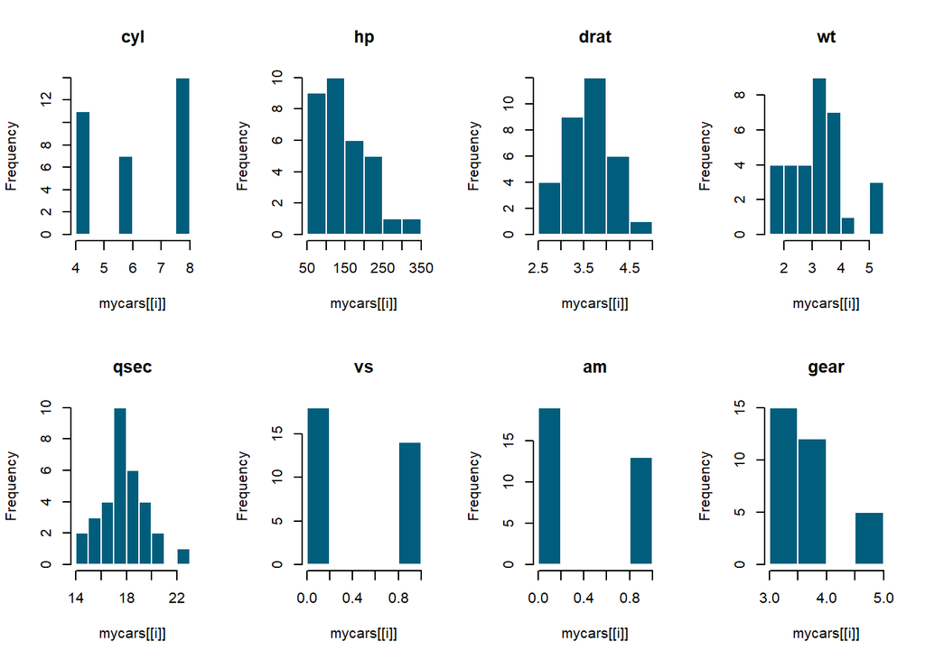

```r
par(mfrow=c(2,4))
for (i in c(2,4:10)) hist(mycars[[i]],main=colnames(mycars)[i], col = "#005E7C", border ="white")
```

We have to use logistic regression to predict vs, using two metric variables in the data set, gear (number of forward gears) and hp (horsepower).

```r
round(cor(mycars[,c(2,4:10)]),2)
```

|  | cyl | hp | drat | wt | qsec | vs | am | gear |
| --- | --- | --- | --- | --- | --- | --- | --- | --- |
| cyl | 1.00 | 0.83 | -0.70 | 0.78 | -0.59 | -0.81 | -0.52 | -0.49 |
| hp | 0.83 | 1.00 | -0.45 | 0.66 | -0.71 | -0.72 | -0.24 | -0.13 |
| drat | -0.70 | -0.45 | 1.00 | -0.71 | 0.09 | 0.44 | 0.71 | 0.70 |
| wt | 0.78 | 0.66 | -0.71 | 1.00 | -0.17 | -0.55 | -0.69 | -0.58 |
| qsec | -0.59 | -0.71 | 0.09 | -0.17 | 1.00 | 0.74 | -0.23 | -0.21 |
| vs | -0.81 | -0.72 | 0.44 | -0.55 | 0.74 | 1.00 | 0.17 | 0.21 |
| am | -0.52 | -0.24 | 0.71 | -0.69 | -0.23 | 0.17 | 1.00 | 0.79 |
| gear | -0.49 | -0.13 | 0.70 | -0.58 | -0.21 | 0.21 | 0.79 | 1.00 |

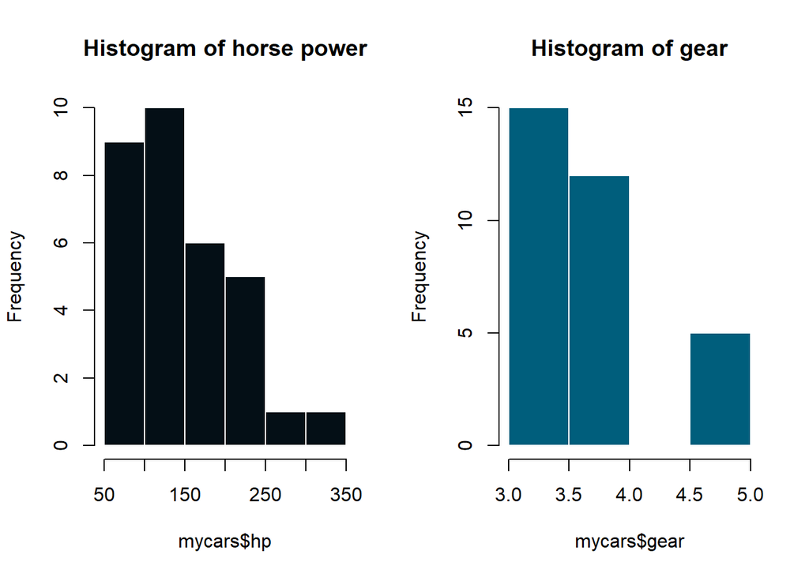

```r
par(mfrow = c(1,2))
hist(mycars$hp, main =  "Histogram of horse power",
     col = "#040F16", border = "white")
hist(mycars$gear, main =  "Histogram of gear",
     col = "#005E7C", border = "white")
```

Both predictors are not normally distributed. The range for “hp” is from approximately 50 to 350, and the range for gear varies from 3 to 5.

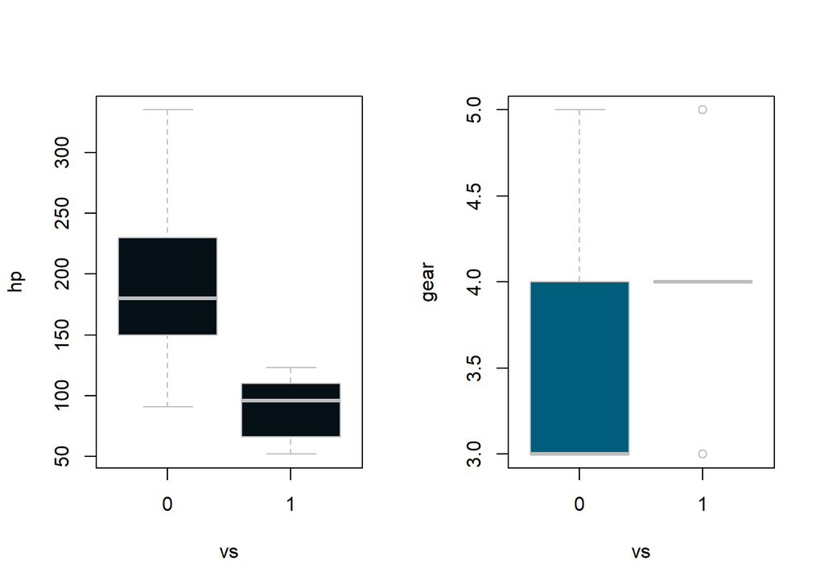

```r
mycars$vs <- as.factor(mycars$vs)
par(mfrow=c(1,2))
boxplot(hp~vs, data = mycars, col = "#040F16", border = "gray")
boxplot(gear~vs, data = mycars, col = "#005E7C", border = "gray")
```

The Distribution of grear has outliers. It looks like mostly only gear 4 has straight engine. There is some overlaping. So the qestion here if “hp” going to be a good predictor.

#### GLM Output

```r
glmOut <- glm(formula = vs ~ hp + gear,
              family = binomial(link="logit"),
              data = mycars)
summary(glmOut)
```

```
##
## Call:
## glm(formula = vs ~ hp + gear, family = binomial(link = "logit"),
##     data = mycars)
##
## Deviance Residuals:
##      Min        1Q    Median        3Q       Max
## -1.76095  -0.20263  -0.00889   0.38030   1.37305
##
## Coefficients:
##             Estimate Std. Error z value Pr(>|z|)
## (Intercept) 13.43752    7.18161   1.871   0.0613 .
## hp          -0.08005    0.03261  -2.455   0.0141 *
## gear        -0.96825    1.12809  -0.858   0.3907
## ---
## Signif. codes:  0 '***' 0.001 '**' 0.01 '*' 0.05 '.' 0.1 ' ' 1
##
## (Dispersion parameter for binomial family taken to be 1)
##
##     Null deviance: 43.860  on 31  degrees of freedom
## Residual deviance: 16.013  on 29  degrees of freedom
## AIC: 22.013
##
## Number of Fisher Scoring iterations: 7
```

In the equation we can see the “link function” - in this case indicating binomial(). By specifying “binomial()” we invoke the inverse logit as the basis of fitting the X variables(“hp” and “gear”) to the Y variable (“vs”).

The “Deviance Residuals” show diagnostic information about the distribution of the residuals after the model is fit. The mean of the residuals should be always 0, in our case slightly over 0.

```r
mean(residuals(glmOut))
```

```
## [1] 0.0149602
```

The fact that the median residual is slightly negative suggest that the distribution of the residuals is slightly positive skewed.

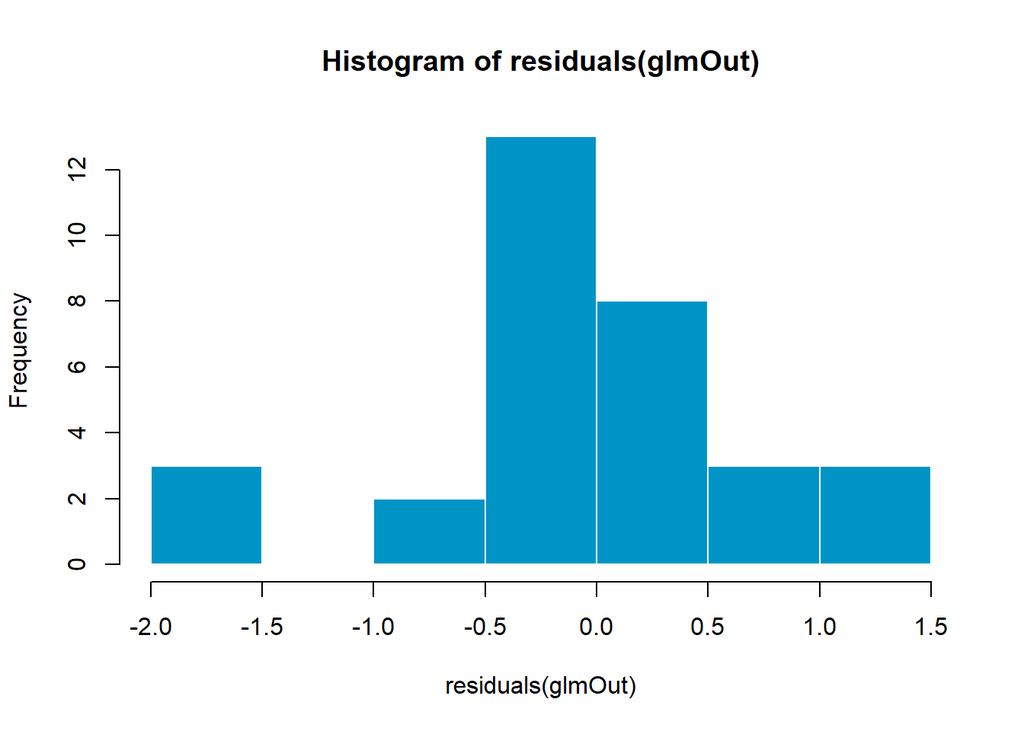

```r
hist(residuals(glmOut), col = "#0094C6", border = "white")
```

These residuals represent error of prediction. If there is residual that is strongly positive or strongly negative, it might suggest problem, such as present of an outlier like in this case.

The output shows that the **intercept** is *not significantly different from 0*. The value of the intercept is not very meaningful to us, but we must keep it in the model to make sure that other coefficient are calibrated correctly.

The coefficient on the **“hp”** predictor is *statistically significant*, based on the Wald`s z-test value of -2.46 and the associated p-value. Because p-value (0.0141) <.05 we can reject the null hypothesis that the log-odds of “hp” is 0 in the population. The Wald’s z-test is calculated by dividing the coefficient value by the standard error.

The tiny coefficient of **“gear”** is *not significantly different from 0*, based on a Wald`s z-test value of -0.86 and associated p-value of 0.3907. Thus we *fail to reject* the null hypothesis that the log-odds of “gear” is equal to 0 in the population.

All these coefficients are log-odds values, we need to convert them to regular odds for easier interpretation.

```r
confint(glmOut)
```

|  | 2.5 % | 97.5 % |
| --- | --- | --- |
| (Intercept) | 2.2528323 | 32.536254 |
| hp | -0.1683153 | -0.033567 |
| gear | -3.7010673 | 1.056678 |

```r
exp(cbind(OR = coef(glmOut), confint(glmOut)))
```

|  | OR | 2.5 % | 97.5 % |
| --- | --- | --- | --- |
| (Intercept) | 6.852403e+05 | 9.5146461 | 1.349944e+14 |
| hp | 9.230734e-01 | 0.8450873 | 9.669901e-01 |
| gear | 3.797461e-01 | 0.0246972 | 2.876797e+00 |

```r
# round(9.669901e-01, digits = 2) #0.97 - for hp 0.85 to 0.97
# round(2.876797e+00, digits = 2) #2.88 - for gear 0.02 to 2.88 # straddle with 1
```

The confidence interval for “gear” stradles with 1:1, confirming the nonsignificant results for that coefficient. The definition of CI is that if you constructed a very large number of similar experiments based on new samples, 95% of the CI you would calculate would contain the population value.

We have to take a look at the deviance too.

**Null deviance: 43.860 on 31 degrees of freedom**

**Residual deviance: 16.013 on 29 degrees of freedom**

**AIC: 22.013**

**Number of Fisher Scoring iterations: 7**

The difference between the null model and the residual model is distributed as chi-square and can be used as an omnibus test.

```r
# Compare null model to two predictor model
anova(glmOut, test = "Chisq")
```

|  | Df | Deviance | Resid. Df | Resid. Dev | Pr(>Chi) |
| --- | --- | --- | --- | --- | --- |
| NULL | NA | NA | 31 | 43.86011 | NA |
| hp | 1 | 27.0225283 | 30 | 16.83758 | 0.0000002 |
| gear | 1 | 0.8244408 | 29 | 16.01314 | 0.3638850 |

The first chi-square test shows a difference of 27.0225 on the one degree of freedom for model with just “hp” as predictor which is statistically significant. The second chi-square test of 0.8244 had “hp” and “gear” as predictors and is not statistically significant. Adding the second predictor didn`t segnifucantly reduced the residual deviance. These results make sense in the light of the significance test on the coefficients and confirms the utility of a model that contains only “hp”.

```r
table(round(predict(glmOut, type= "response")), mycars$vs)
```

| / | 0 | 1 |
| --- | --- | --- |
| 0 | 15 | 3 |
| 1 | 3 | 11 |

The off diagonal items, 3 and 3 are all the errorneous predictions.

```r
## Overall accuracy
(15+11)/32
```

```
## [1] 0.8125
```

```r
(3+3)/32 # error rate
```

```
## [1] 0.1875
```

The overall accuracy was 81%.

#### Bayesian Analysis

```r
mycars$vs <- as.numeric(mycars$vs)- 1
bayesLogitOut <- MCMClogit(formula = vs ~ hp+gear, data = mycars)
summary(bayesLogitOut)
```

```
##
## Iterations = 1001:11000
## Thinning interval = 1
## Number of chains = 1
## Sample size per chain = 10000
##
## 1. Empirical mean and standard deviation for each variable,
##    plus standard error of the mean:
##
##                Mean      SD  Naive SE Time-series SE
## (Intercept) 18.5047 8.82570 0.0882570       0.339443
## hp          -0.1087 0.04119 0.0004119       0.001671
## gear        -1.3983 1.34302 0.0134302       0.047170
##
## 2. Quantiles for each variable:
##
##                2.5%     25%    50%      75%    97.5%
## (Intercept)  4.4716 12.0818 17.500 23.66161 39.08301
## hp          -0.2042 -0.1337 -0.103 -0.07784 -0.04555
## gear        -4.4295 -2.1901 -1.306 -0.47733  0.93486
```

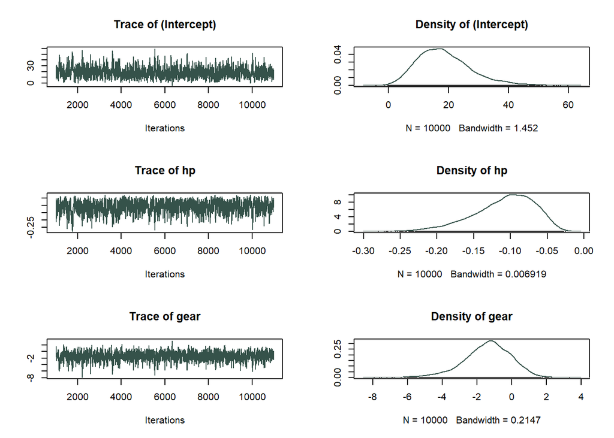

```r
plot(bayesLogitOut, col = "#35524A", border = "white")
```

The output of MCMC focuses on describing the distribution of the parameters representing both the intercept and the coefficients of “hp” and “gear”, calibrated in log-odds.

The point estimates in the current output are listed under the “Mean” column and are similar to the output from the traditional logistic regression. The next column “SD” corresponds to the standard error in the output. The most common points of interest will be the log-odd coefficients of the two predictors. One of them is for “hp” -0.1087 and the other is “gear” -1.39. In the second output we can clearly see that the HDI for “gear” overlap with 0, so the population parameter for “gear” lies somewhere near 0. We need to convert “hp” to plain odds in order to interpret it, because the iinterval does not overlap with 0 and we can use that predictor.

We can improve our view of the parameter estimates of the coefficient by converting the distribution from log odds to plain odds.

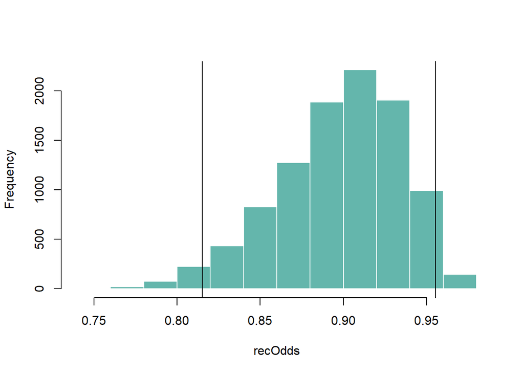

```r
recLogOdds <- as.matrix(bayesLogitOut[,"hp"])
recOdds <- apply(recLogOdds,1,exp)
hist(recOdds, main=NULL, col = "#64B6AC", border = "white")
abline(v=quantile(recOdds,probs=c(0.025,0.975)))
```

```r
# mean(recOdds) # 0.8977491
```

**5. As noted in the chapter, the BaylorEdPsych add‑in package contains a procedure for generating pseudo‑R‑squared values from the output of the glm() procedure. Use the results of Exercise 1 to generate, report, and interpret a Nagelkerke pseudo‑R‑squared value.**

```r
PseudoR2(glmOut)
```

```
##         McFadden     Adj.McFadden        Cox.Snell       Nagelkerke
##        0.6349042        0.4525061        0.5811397        0.7789526
## McKelvey.Zavoina           Effron            Count        Adj.Count
##        0.8972195        0.6445327        0.8125000        0.5714286
##              AIC    Corrected.AIC
##       22.0131402       22.8702830
```

R- square summarizes the overall goodness of the model.

A pseudo R-squared only has meaning when compared to another pseudo R-squared of the same type, on the same data, predicting the same outcome. The interpretation is: “the proportion of the total variability of the outcome that is accounted for by the model”.In this situation, the higher pseudo R-squared indicates which model better predicts the outcome.

Cox and Snell’s(.58) is based on the log likelihood for the model compared to the log likelihood for a baseline model. However, with categorical outcomes, it has a theoretical maximum value of less than 1, even for a “perfect” model. Nagelkerke is an adjusted version of the Cox & Snell R-square that adjusts the scale of the statistic to cover the full range from 0 to 1. The model with the largest R square statistic is “best” according to this measurelike we said earlier.

If we examine Nagelkerke(0.7789526) we can interpret it as the proportion of variance in the outcome variable(“vs”) accounted by the predictor variables (“hp” and “gear”). The value is good for R-square (really close to 1). Given out that only “hp” as significant, these results suggest that “hp” has moderate role for accounting for the “vs” variable. This returns us to the idea of the statistical power.

**6. Continue the analysis of the Chile data set described in this chapter. The data set is in the “car” package, so you will have to install.packages() and library() that package first, and then use the data(Chile) command to get access to the data set. Pay close attention to the transformations needed to isolate cases with the Yes and No votes as shown in this chapter. Add a new predictor, statusquo, into the model and remove the income variable. Your new model specification should be vote ~ age + statusquo. The statusquo variable is a rating that each respondent gave indicating whether they preferred change or maintaining the status quo. Conduct general linear model and Bayesian analysis on this model and report and interpret all relevant results. Compare the AIC from this model to the AIC from the model that was developed in the chapter (using income and age as predictors).**

```r
data(Chile)

## Grab Yes votes
ChileY <- Chile[Chile$vote == "Y",]
## Grab No votes
ChileN <- Chile[Chile$vote == "N",]

## Create new data set
ChileYN <- rbind(ChileY, ChileN)
ChileYN <- ChileYN[complete.cases(ChileYN),]

## Simplify the factor
ChileYN$vote <- factor(ChileYN$vote, levels = c("N","Y"))
```

We can create boxplots to represent ranges for each of the predictors, divided by Yes and No votes.

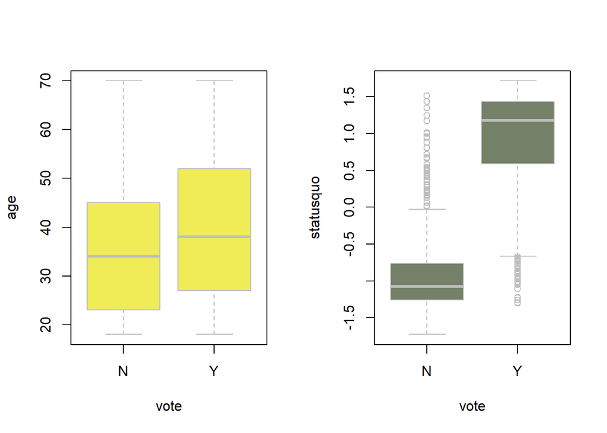

```r
par(mfrow = c(1,2))
boxplot(age~vote, data = ChileYN, col = "#F0EC57", border = "gray")
boxplot(statusquo~vote, data = ChileYN, col = "#748067", border = "gray")
```

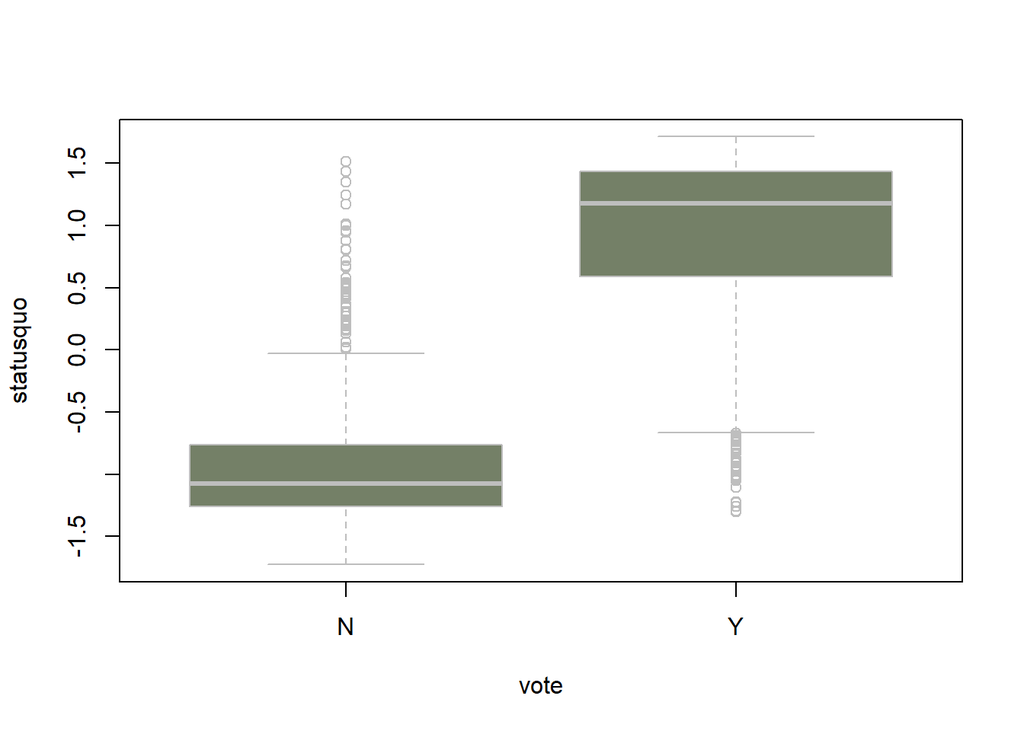

```r
## Displaing all the outliers
# boxplot(statusquo~vote, data = ChileYN,
        # col = "#748067", border = "gray")$out

## Assign the outlier values into a vector
outliers <- boxplot(statusquo~vote, data = ChileYN,
        col = "#748067", border = "gray")$out
```

```r
print(outliers)
```

```
##  [1]  1.16851  0.52845  0.71898  0.15214  0.41711  0.02178  0.21063  0.53257
##  [9]  0.41980  0.19175  0.01279  1.01110  0.06239  1.51284  0.43869  1.43203
## [17]  0.95611  0.00720  0.36676  0.24220  0.50186  0.22900  0.57763  0.67327
## [25]  0.51637  0.41409  1.35000  0.99704  0.22416  0.46682  0.34221  0.42371
## [33]  0.27038  0.66365  0.87797  0.80245  0.50129  0.19955  0.13025  0.45050
## [41]  0.81038  0.53171  0.49426  0.51557  0.54349  0.51627  0.94765  0.29437
## [49]  0.30916  1.24288  0.16797 -1.10784 -0.97742 -0.91124 -0.82983 -0.87318
## [57] -1.23032 -0.93686 -1.00723 -1.30351 -0.76832 -0.89149 -0.69048 -0.88666
## [65] -1.05197 -0.72379 -1.29617 -1.25899 -1.02236 -0.71844 -0.67418 -0.79979
## [73] -1.04094 -0.78735 -0.70916 -0.94732 -0.74140 -1.22114 -1.02512
```

```r
# ChileYN <- ChileYN[-which(ChileYN$statusquo %in% outliers),]
# boxplot(ChileYN$statusquo)
```

Lets use logistic regression to see if we can scientifically predict a Yes or No vote based on the age and statusquo level of a person who responded to the poll:

#### GLM Output

```r
chOut <- glm(formula = vote ~ statusquo + age, family = binomial(),
             data = ChileYN)
summary(chOut)
```

```
##
## Call:
## glm(formula = vote ~ statusquo + age, family = binomial(), data = ChileYN)
##
## Deviance Residuals:
##     Min       1Q   Median       3Q      Max
## -3.2095  -0.2830  -0.1840   0.1889   2.8789
##
## Coefficients:
##              Estimate Std. Error z value Pr(>|z|)
## (Intercept) -0.193759   0.270708  -0.716   0.4741
## statusquo    3.174487   0.143921  22.057   <2e-16 ***
## age          0.011322   0.006826   1.659   0.0972 .
## ---
## Signif. codes:  0 '***' 0.001 '**' 0.01 '*' 0.05 '.' 0.1 ' ' 1
##
## (Dispersion parameter for binomial family taken to be 1)
##
##     Null deviance: 2360.29  on 1702  degrees of freedom
## Residual deviance:  734.52  on 1700  degrees of freedom
## AIC: 740.52
##
## Number of Fisher Scoring iterations: 6
```

In the equation we can see the “link function” - in this case indicating binomial(). By specifying “binomial()” we invoke the inverse logit as the basis of fitting the X variables(“age” and “statusquo”) to the Y variable (“vote”).

The “Deviance Residuals” show diagnostic information about the distribution of the residuals after the model is fit. The mean of the residuals is always 0 in our case slightly under 0.

```r
mean(residuals(chOut))
```

```
## [1] -0.02173092
```

The fact that the median residual is slightly negative suggest that the distribution of the residuals is slightly positive skewed.

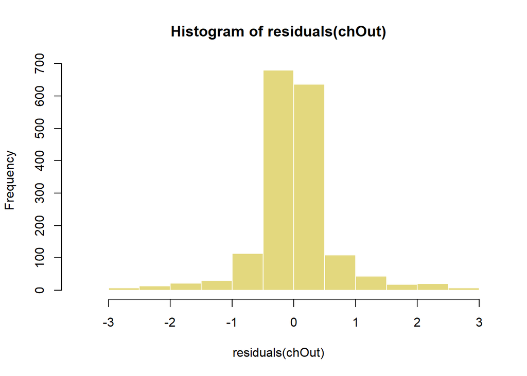

```r
hist(residuals(chOut), col = "#E3D87E", border = "white")
```

These residuals represent error of prediction. If there is residual that is strongly positive or strongly negative, it might suggest problem, such as present of an outlier.

The output shows that the **intercept** is *not significantly different from 0*. The value of the intercept is not very meaningful to us, but we must keep it in the model to make sure that other coefficient are calibrated correctly.

The coefficient on the **“statusquo”** predictor is *statistically significant*, based on the Wald`s z-test value of 22.057 and the associated p-value. Because p-value (2e-16 ***) <.001 we can reject the null hypothesis that the log-odds of “statusquo” is 0 in the population. The Wald’s z-test is calculated by dividing the coefficient value by the standard error.

The tiny coefficient of **“age”** is *not significantly different from 0*, based on a Wald`s z-test value of 1.659 and associated p-value of 0.0972. Thus we *fail to reject* the null hypothesis that the log-odds of “age” is equal to 0 in the population.

All these coefficients are log-odds values, we need to convert them to regular odds for easier interpretation. In this case we only significant is “statusquo”.

```r
confint(chOut)
```

|  | 2.5 % | 97.5 % |
| --- | --- | --- |
| (Intercept) | -0.7242110 | 0.3385679 |
| statusquo | 2.9040747 | 3.4690947 |
| age | -0.0020686 | 0.0247244 |

```r
exp(cbind(OR = coef(chOut), confint(chOut)))
```

|  | OR | 2.5 % | 97.5 % |
| --- | --- | --- | --- |
| (Intercept) | 0.8238564 | 0.4847068 | 1.402937 |
| statusquo | 23.9145451 | 18.2483505 | 32.107663 |
| age | 1.0113863 | 0.9979335 | 1.025033 |

We should calculate and report the results from the chi-square test.

```r
anova(chOut, test = "Chisq")
```

|  | Df | Deviance | Resid. Df | Resid. Dev | Pr(>Chi) |
| --- | --- | --- | --- | --- | --- |
| NULL | NA | NA | 1702 | 2360.2950 | NA |
| statusquo | 1 | 1623.026234 | 1701 | 737.2687 | 0.0000000 |
| age | 1 | 2.748047 | 1700 | 734.5207 | 0.0973733 |

Each successive line of the output, we lose a degree of freedom each time we enter a new predictor. The column “Deviance Resid” is the chi-square value for the effect of the predictor, while “Dev” is the chi-square that represent what is unaccounted for in the dependent variable after the entry of each predictor in the model.

To close our consideration of the output of glm(), we will reproduced few lines from the output earlier.

**Null deviance: 2360.29 on 1702 degrees of freedom**

**Residual deviance: 734.52 on 1700 degrees of freedom**

**AIC: 740.52**

**Number of Fisher Scoring iterations: 6**

```r
table(round(predict(chOut, type= "response")), ChileYN$vote)
```

| / | N | Y |
| --- | --- | --- |
| 0 | 810 | 74 |
| 1 | 57 | 762 |

```r
## Overall accuracy
(810+762)/(810+74+57+762) #92%
```

```
## [1] 0.9230769
```

```r
(74+57)/(810+74+57+762) # error rate 8%
```

```
## [1] 0.07692308
```

We can say that is a really good model.

We tested a measures of age and statusquo to see if they could predict the vote of people in Chile. A chi-square omnibus test on the result of logistic regression was significant for model with the one predictor, chisq (1) = 1623.03, p<.0001. Only the Wald`s z-test on the statusquo coefficient was significant, z= 22.057, p <.05. When converted to odds, the coefficient was 23.91 suggesting that for each individual that who wants to maintain statusquo, the odds of that person voting Yes is 23.91:1. This is a strong evidence suggesting that statusquo could serve az a useful vote predictor. The 95% CI for statusquo range from low 18.24:1 up to 32.10, expressed in plain odd. If the study was represented 100 times, 95% of the similarly constructed intervals would contain the population value.

#### Bayesian Analysis

```r
## Adjust the outcome variable
ChileYN$vote <- as.numeric(ChileYN$vote)- 1

bayesLogitOut1 <- MCMClogit(formula = vote ~ statusquo + age, data = ChileYN)
summary(bayesLogitOut1)
```

```
##
## Iterations = 1001:11000
## Thinning interval = 1
## Number of chains = 1
## Sample size per chain = 10000
##
## 1. Empirical mean and standard deviation for each variable,
##    plus standard error of the mean:
##
##                 Mean       SD  Naive SE Time-series SE
## (Intercept) -0.19230 0.270280 2.703e-03      0.0088240
## statusquo    3.19813 0.141422 1.414e-03      0.0046907
## age          0.01123 0.006917 6.917e-05      0.0002295
##
## 2. Quantiles for each variable:
##
##                 2.5%       25%      50%       75%   97.5%
## (Intercept) -0.73688 -0.367807 -0.18743 -0.007969 0.32179
## statusquo    2.91721  3.104102  3.19802  3.292425 3.48629
## age         -0.00235  0.006636  0.01107  0.015803 0.02556
```

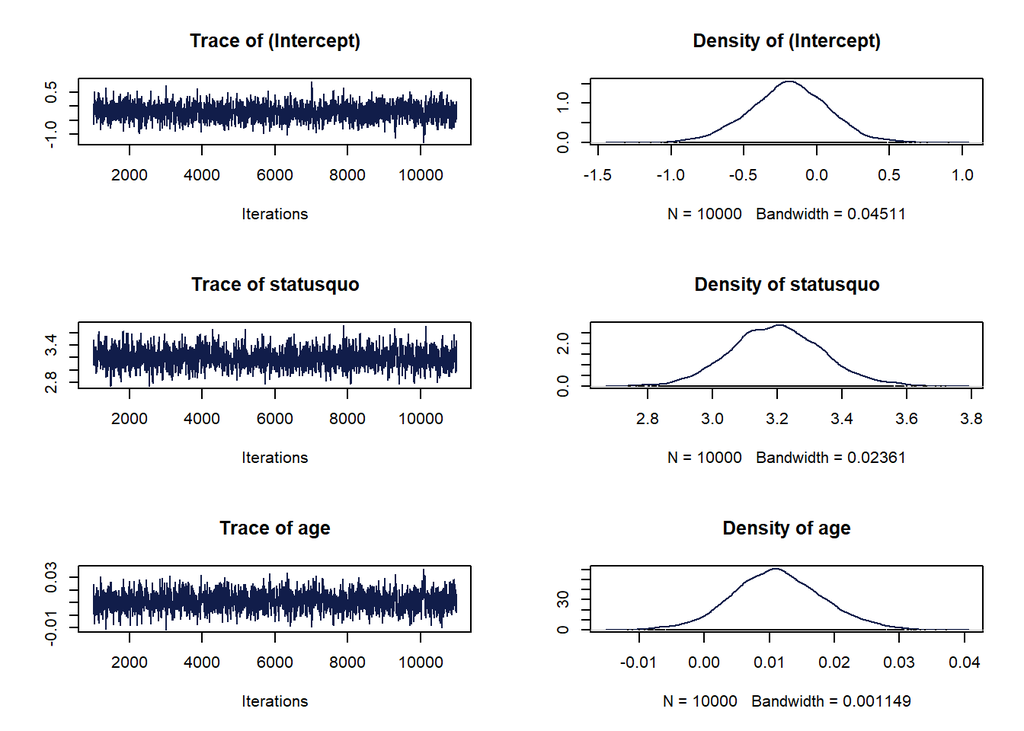

```r
plot(bayesLogitOut1, col = "#111D4A")
```

Trace plots show the progress of the MCMC estimation process. Density plots show the posterior distribution of each coefficient. “age” is centered near 0 which confirm that there isn`t much going on with that variable and might not be a good predictor. Intercept also centers around 0. They are all quite normally shaped and the central region of 95% under the curve is where in all likelihood the parameter of interest lies.

The output of MCMC focuses on describing the distribution of the parameters representing both the intercept and the coefficients of age and statusquo, calibrated in log-odds.

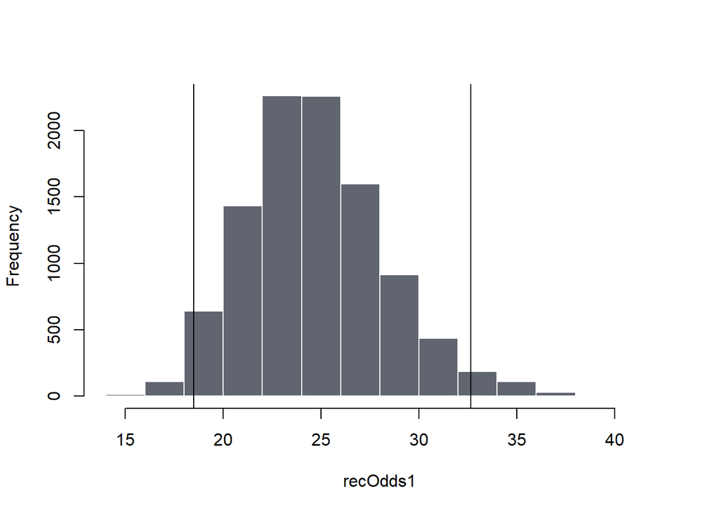

```r
recLogOdds1 <- as.matrix(bayesLogitOut1[,"statusquo"])
recOdds1 <- apply(recLogOdds1,1,exp)
hist(recOdds1, main=NULL, col = "#60656F", border = "white")
abline(v=quantile(recOdds1,probs=c(0.025,0.975)))
```

```r
mean(recOdds1) # 24.73367
```

```
## [1] 24.73367
```

The histogram shows almost symmetric distribution centered about 24.73, consistent with the results that we obtained from glm() and suggesting an increase of about 24.73:1 in likelihood of Yes vote. The HDI spans a region starting at as low as 18.49 and ranging as high as 32.66. These boundaries are really close to those of the CI we obtained from glm(). HDI gives us a direct view of the most likely range of coefficient values in the population.

**7. Bonus R code question: Develop your own custom function that will take the posterior distribution of a coefficient from the output object from an MCMClogit() analysis and automatically create a histogram of the posterior distributions of the coefficient in terms of regular odds (instead of log‑odds). Make sure to mark vertical lines on the histogram indicating the boundaries of the 95% HDI.**

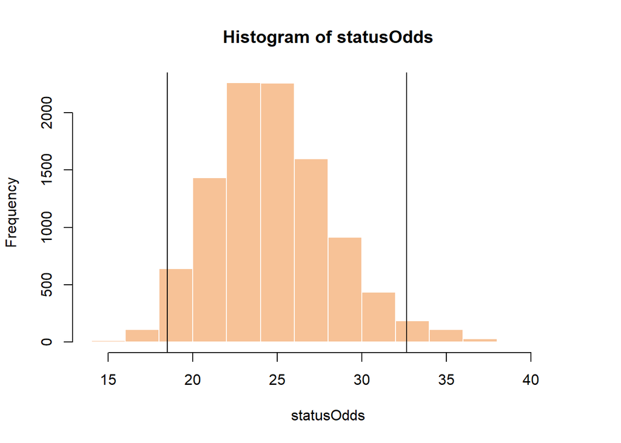

```r
logFuncHist <- function(logO){
 statusQuoLogOdds <- as.matrix(logO[,"statusquo"])
 statusOdds <- apply(statusQuoLogOdds,1,exp)
 hist(statusOdds, col = "#f7c297", border = "white")
 abline(v=quantile(statusOdds,c(.025)),col='black')
 abline(v=quantile(statusOdds,c(.975)),col='black')
}
logFuncHist(bayesLogitOut1)
```